# Systolic blood pressure in adults aged 30 and over in Bharatpur, Nepal

Dataset 3: Nepal hypertension and cardiovascular risk-factor survey

RSR feasibility analysis

2026-08-03

# Introduction

This is a community-based cross-sectional survey of adults aged 30 years and over living in Bharatpur, Chitwan district, Nepal, carried out to estimate the prevalence of hypertension and its behavioural and anthropometric correlates (Dhungana and colleagues, *PLOS ONE* 2016, e0185806). Blood pressure was measured twice on each participant with a digital sphygmomanometer and the two readings averaged; alongside this, the WHO STEPS instrument was used to collect tobacco, alcohol, diet and physical-activity information, and height and weight were measured directly. Systolic blood pressure is analysed here on its continuous scale because dichotomising it at 140 mmHg discards most of the variation and, in this dataset, produces an outcome that is partly defined by medication use.

**Aim.** Among adults aged 30 and over in Bharatpur, we examined which of sex, age band, education, occupation, poverty, smoking, smokeless tobacco, alcohol, fruit and vegetable intake, salt intake, physical activity, family history of hypertension and body mass index are independently associated with mean systolic blood pressure, mutually adjusting for the others.

This is a *Purpose 3* analysis: several predictors are of interest and the question is which remain associated with the outcome after mutual adjustment.

# Methods

**Data source.** A cross-sectional survey of 1159 adults aged 30 years and over resident in Bharatpur Municipality, Chitwan, Nepal. The source study used multistage cluster sampling: four wards were selected at random and approximately 300 participants were enrolled in each, with the sample size calculation assuming a design effect of 1.5. **The ward identifier is not present in this extract**, which has direct consequences for the standard errors reported below (see Limitations). Each row is one participant.

**Variables.** The outcome is `systolic_bp`, the mean of two systolic readings in mmHg. Predictors are sex (reference *Female*); age band in years (reference *30-39*; the survey recorded age only in four bands, so no per-year effect can be estimated); education (reference *None or informal*); main occupation (reference *Household work*); family income per head below the poverty line (reference *No*); smoking status (reference *Never*); current smokeless tobacco use (reference *No*); any alcohol in the last month (reference *No*); fruit and vegetable servings per day (continuous); estimated salt intake in g/day (continuous); physical activity level (reference *Moderate or high*); family history of hypertension (reference *No*); and body mass index in kg/m2 (continuous). These thirteen cover the classical modifiable and non-modifiable determinants of blood pressure that the STEPS instrument was designed to capture.

Three pairs of variables in this file measure the same thing twice and only one member of each pair may enter a model. `physical_activity` is a deterministic cut of `mets_min_per_week` at 600 MET-minutes per week (the “Low” group spans 0-600, the “Moderate or high” group 620-29,260); the categorical version is used here because it is the WHO STEPS classification the source paper reports and because the continuous version is extremely right-skewed. `smoking_status` and `cigarettes_per_week` are the same construct, with `cigarettes_per_week` equal to zero for every never-smoker; `smoking_status` is used because it separates former from never smokers, which turns out to matter. Finally `hypertension` is *defined* as raised measured blood pressure or current antihypertensive treatment, so it, `bp_awareness` and `antihypertensive_drug` are all downstream of the outcome and are excluded as predictors.

**Statistical analysis.** Linear regression via `lm()`, justified because the outcome is continuous. We fitted a univariable model for each predictor first, then a single multivariable model containing all of them. Predictors were chosen in advance on subject-matter grounds, not by significance. Significance threshold 0.05; estimates are reported with 95% confidence intervals. Assumptions were checked with `performance::check_model()`, and because non-constant error variance was flagged, heteroscedasticity-consistent (HC3) standard errors are reported alongside the ordinary ones. Analysis used R version 4.6.0 (2026-04-24) with tidyverse, gtsummary, performance and sandwich.

**Missing data.** Complete-case analysis: 1159 of 1159 rows were analysed (0 dropped). Every variable in this file is 100% complete, so listwise deletion removes no rows at all and there is no missing-data story to tell: no imputation, no complete-case selection bias, nothing to sensitivity-test.

# Results

## Sample characteristics

**Table 1. Sample characteristics.**

| **Characteristic** | **N** | **N = 1,159**<sup>1</sup> |
| --- | --- | --- |
| Systolic blood pressure (mmHg) | 1,159 | 120 (110, 139) |
| Sex | 1,159 |  |
| Female |  | 824 (71%) |
| Male |  | 335 (29%) |
| Age band (years) | 1,159 |  |
| 30-39 |  | 383 (33%) |
| 40-49 |  | 295 (25%) |
| 50-59 |  | 218 (19%) |
| 60 or more |  | 263 (23%) |
| Education | 1,159 |  |
| None or informal |  | 626 (54%) |
| Primary |  | 136 (12%) |
| Secondary |  | 239 (21%) |
| Higher |  | 158 (14%) |
| Main occupation | 1,159 |  |
| Household work |  | 659 (57%) |
| Agriculture or labour |  | 142 (12%) |
| Job or self-employed |  | 305 (26%) |
| Unemployed |  | 53 (4.6%) |
| Below poverty line | 1,159 | 316 (27%) |
| Smoking status | 1,159 |  |
| Never |  | 770 (66%) |
| Former |  | 180 (16%) |
| Current |  | 209 (18%) |
| Smokeless tobacco use | 1,159 | 139 (12%) |
| Alcohol in the last month | 1,159 | 177 (15%) |
| Fruit and vegetable servings per day | 1,159 | 2.29 (1.43, 3.14) |
| Salt intake (g/day) | 1,159 | 2.85 (1.90, 4.55) |
| Physical activity level | 1,159 |  |
| Moderate or high |  | 744 (64%) |
| Low |  | 415 (36%) |
| Family history of hypertension | 1,159 | 170 (15%) |
| Body mass index (kg/m2) | 1,159 | 23.6 (21.0, 26.4) |

<sup>1</sup> Median (Q1, Q3); n (%)

Mean systolic blood pressure was 123.1 mmHg (SD 20.2), with a long right tail reaching 200 mmHg. The sample is 71.1% female and 22.7% aged 60 or over, reflecting the daytime household recruitment used in the source survey; men are therefore under-represented relative to the municipal population. 131 participants (11.3%) were taking antihypertensive medication at the time of measurement, and their mean systolic pressure was 139.8 mmHg against 121 mmHg in the untreated – still higher, but pharmacologically lowered from whatever their untreated value would have been. This is the central interpretive problem for this outcome and is returned to throughout.

## Exploratory figure

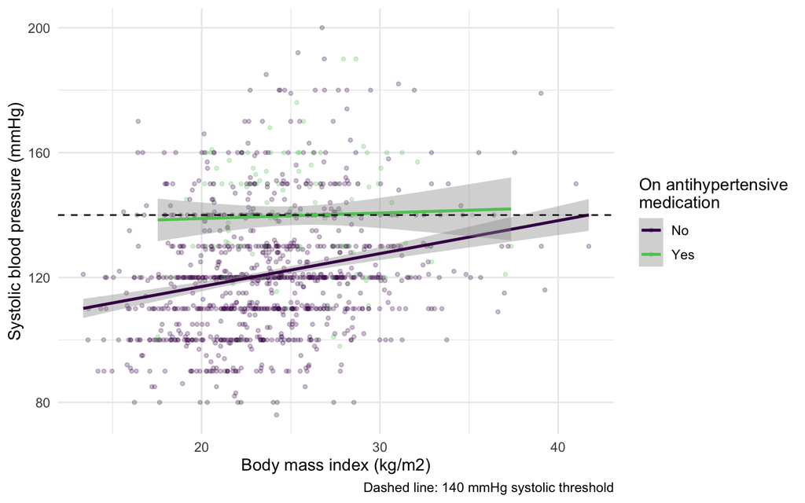

Figure 1. Systolic blood pressure against body mass index, separately for participants taking and not taking antihypertensive medication, with linear smoothers. The dashed line marks the 140 mmHg threshold.

Systolic pressure rises steadily with body mass index in the untreated (1.05 mmHg per kg/m2) but is almost flat in the treated (0.18 mmHg per kg/m2), and the treated line sits well above the untreated one across the whole BMI range. Both features are treatment artefacts: the vertical gap is a *treated* gap and so understates the true difference between people who need medication and people who do not, while the flat treated slope is what happens when the highest readings in a group are the ones most aggressively medicated.

## Univariable models

| **Characteristic** | **N** | **Beta** | **95% CI** | **p-value** |
| --- | --- | --- | --- | --- |
| Sex | 1,159 |  |  |  |
| Female |  | — | — |  |
| Male |  | 7.9 | 5.3, 10 | <0.001 |
| Age band (years) | 1,159 |  |  |  |
| 30-39 |  | — | — |  |
| 40-49 |  | 6.7 | 3.8, 9.6 | <0.001 |
| 50-59 |  | 11 | 8.0, 14 | <0.001 |
| 60 or more |  | 18 | 15, 21 | <0.001 |
| Education | 1,159 |  |  |  |
| None or informal |  | — | — |  |
| Primary |  | -5.8 | -9.5, -2.0 | 0.002 |
| Secondary |  | -6.0 | -9.0, -3.0 | <0.001 |
| Higher |  | -4.8 | -8.3, -1.3 | 0.007 |
| Main occupation | 1,159 |  |  |  |
| Household work |  | — | — |  |
| Agriculture or labour |  | 2.2 | -1.5, 5.8 | 0.2 |
| Job or self-employed |  | 2.0 | -0.76, 4.7 | 0.2 |
| Unemployed |  | 12 | 6.4, 18 | <0.001 |
| Below poverty line | 1,159 |  |  |  |
| No |  | — | — |  |
| Yes |  | 2.1 | -0.54, 4.7 | 0.12 |
| Smoking status | 1,159 |  |  |  |
| Never |  | — | — |  |
| Former |  | 14 | 11, 17 | <0.001 |
| Current |  | 4.5 | 1.6, 7.5 | 0.003 |
| Smokeless tobacco use | 1,159 |  |  |  |
| No |  | — | — |  |
| Yes |  | 6.7 | 3.2, 10 | <0.001 |
| Alcohol in the last month | 1,159 |  |  |  |
| No |  | — | — |  |
| Yes |  | 10 | 6.8, 13 | <0.001 |
| Fruit and vegetable servings per day | 1,159 | 0.39 | -0.54, 1.3 | 0.4 |
| Salt intake (g/day) | 1,159 | 0.06 | -0.45, 0.58 | 0.8 |
| Physical activity level | 1,159 |  |  |  |
| Moderate or high |  | — | — |  |
| Low |  | 4.4 | 2.0, 6.8 | <0.001 |
| Family history of hypertension | 1,159 |  |  |  |
| No |  | — | — |  |
| Yes |  | 2.0 | -1.3, 5.3 | 0.2 |
| Body mass index (kg/m2) | 1,159 | 1.1 | 0.86, 1.4 | <0.001 |

Abbreviation: CI = Confidence Interval

Body mass index is the strongest continuous predictor: each additional kg/m2 is associated with a 1.13 mmHg higher systolic pressure (95% CI 0.86 to 1.4, p < 0.001), so across the interquartile range of BMI in this sample (21.0 to 26.4 kg/m2) the crude difference is about 6.1 mmHg. Age is larger still in absolute terms: participants aged 60 or more average 18.4 mmHg above those aged 30-39 (95% CI 15.5 to 21.4). Men average 7.9 mmHg above women (95% CI 5.3 to 10.4). Several of the classical lifestyle risk factors are already flat in the crude models: salt intake is 0.06 mmHg per g/day (95% CI -0.45 to 0.58) and family history of hypertension is 2 mmHg (95% CI -1.3 to 5.3), neither close to significant. Low physical activity, by contrast, does look harmful crudely (4.4 mmHg, 95% CI 2 to 6.8, p <0.001), which is worth holding onto because it does not survive adjustment.

## Why adjustment is needed

The crude estimates above mix several strongly overlapping gradients, and two variables in this dataset do most of the confounding. **Age band** is the clearest: systolic pressure rises about 18 mmHg between the youngest and oldest bands, and age is simultaneously associated with almost every candidate exposure here – former smokers are concentrated in the older bands, education is far lower in the older bands (209 of the 263 participants aged 60 or more have no or informal schooling, against 114 of 383 in the 30-39 band), and BMI itself falls in the oldest band. Any crude “education effect” on blood pressure is therefore partly an age effect wearing a different label. **Sex** is the second: 35% of men are current smokers against 11% of women, alcohol use is similarly concentrated in men, and men have higher systolic pressure for reasons unrelated to either behaviour; so crude alcohol and tobacco coefficients partly measure being male. **Body mass index** plays the same role for the behavioural variables: it is a strong independent predictor of blood pressure and it differs across occupation, poverty and activity groups, so leaving it out would let a socio-economic coefficient absorb an adiposity effect. Mutual adjustment separates these.

## Multivariable model

| **Characteristic** | **Beta** | **95% CI** | **p-value** |
| --- | --- | --- | --- |
| Sex |  |  |  |
| Female | — | — |  |
| Male | 4.2 | 1.2, 7.2 | 0.006 |
| Age band (years) |  |  |  |
| 30-39 | — | — |  |
| 40-49 | 5.0 | 2.2, 7.7 | <0.001 |
| 50-59 | 8.8 | 5.7, 12 | <0.001 |
| 60 or more | 16 | 13, 20 | <0.001 |
| Education |  |  |  |
| None or informal | — | — |  |
| Primary | -3.1 | -6.5, 0.42 | 0.084 |
| Secondary | -2.2 | -5.1, 0.73 | 0.14 |
| Higher | -1.9 | -5.5, 1.7 | 0.3 |
| Main occupation |  |  |  |
| Household work | — | — |  |
| Agriculture or labour | -1.3 | -4.7, 2.1 | 0.5 |
| Job or self-employed | 0.70 | -2.1, 3.5 | 0.6 |
| Unemployed | 5.4 | 0.32, 10 | 0.037 |
| Below poverty line |  |  |  |
| No | — | — |  |
| Yes | 0.44 | -1.9, 2.8 | 0.7 |
| Smoking status |  |  |  |
| Never | — | — |  |
| Former | 8.2 | 5.3, 11 | <0.001 |
| Current | -0.88 | -4.0, 2.3 | 0.6 |
| Smokeless tobacco use |  |  |  |
| No | — | — |  |
| Yes | 2.3 | -1.4, 6.0 | 0.2 |
| Alcohol in the last month |  |  |  |
| No | — | — |  |
| Yes | 6.5 | 3.2, 9.9 | <0.001 |
| Fruit and vegetable servings per day | 0.51 | -0.32, 1.3 | 0.2 |
| Salt intake (g/day) | 0.43 | -0.02, 0.88 | 0.061 |
| Physical activity level |  |  |  |
| Moderate or high | — | — |  |
| Low | 1.0 | -1.2, 3.2 | 0.4 |
| Family history of hypertension |  |  |  |
| No | — | — |  |
| Yes | -0.28 | -3.2, 2.6 | 0.9 |
| Body mass index (kg/m2) | 1.4 | 1.1, 1.6 | <0.001 |

Abbreviation: CI = Confidence Interval

Model fit

| Statistic | Value |
| --- | --- |
| R-squared | 0.266 |
| Adjusted R-squared | 0.253 |
| Residual SD (mmHg) | 17.430 |
| Observations | 1159.000 |
| Model parameters (incl. intercept) | 21.000 |
| Observations per parameter | 55.200 |

The model explains 26.6% of the variance in systolic pressure (adjusted R-squared 0.253), leaving roughly three quarters unexplained – normal for individual-level blood pressure, which is measured with substantial within-person variability. With 1159 observations and 21 parameters there are 55.2 observations per parameter, so the model is not overfitted. Conditional on the other twelve predictors, each additional kg/m2 of BMI is associated with a 1.37 mmHg higher systolic pressure (95% CI 1.12 to 1.62); participants aged 60 or more average 16.3 mmHg above the 30-39 band (95% CI 13.1 to 19.6); men average 4.2 mmHg above women (95% CI 1.2 to 7.2); and participants who drank in the last month average 6.5 mmHg above those who did not (95% CI 3.2 to 9.9).

The smoking result needs care. Former smokers average 8.2 mmHg above never-smokers (95% CI 5.3 to 11.2) while current smokers are indistinguishable from never-smokers (-0.9 mmHg, 95% CI -4 to 2.3). Read causally this is nonsense. Read as reverse causation it is entirely expected: people quit smoking *because* they were told they had high blood pressure or another cardiovascular problem, so “former smoker” is partly a marker of having been diagnosed. Salt intake (0.43 mmHg per g/day, 95% CI -0.02 to 0.88), low physical activity and family history of hypertension all remain null after adjustment.

### Sensitivity analysis: excluding treated participants

Adjusted estimates (mmHg, 95% CI)

All n = 1159; untreated n = 1028

| Term | All participants | Untreated only |
| --- | --- | --- |
| BMI (per kg/m2) | 1.37 (1.12 to 1.62) | 1.32 (1.06 to 1.58) |
| Age 60+ vs 30-39 | 16.32 (13.08 to 19.56) | 14.66 (11.21 to 18.12) |
| Male vs female | 4.22 (1.22 to 7.21) | 4.68 (1.53 to 7.83) |
| Alcohol last month | 6.50 (3.15 to 9.85) | 6.08 (2.50 to 9.66) |

Because 131 participants are on medication that lowers the very quantity being measured, `systolic_bp` in this file is a *partly treated* outcome. Refitting the model in the 1028 untreated participants changes the picture only modestly: the age contrast falls from 16.3 to 14.7 mmHg and the BMI slope from 1.37 to 1.32 mmHg per kg/m2, while sex and alcohol are essentially unchanged. The direction of the bias is predictable: treatment is concentrated in the older, heavier, higher-risk participants and pulls *their* readings down, so the full-sample estimates for age and BMI are, if anything, conservative. Excluding the treated is not a free fix, however – it conditions on a variable caused by the outcome and so introduces its own selection bias – which is why both fits are shown rather than one being declared correct.

## Unadjusted versus adjusted

**Table 2. Unadjusted and adjusted estimates.**

| **Characteristic** | **Unadjusted** **N** | **Unadjusted** **Beta** | **Unadjusted** **95% CI** | **Unadjusted** **p-value** | **Adjusted** **Beta** | **Adjusted** **95% CI** | **Adjusted** **p-value** |
| --- | --- | --- | --- | --- | --- | --- | --- |
| Sex | 1,159 |  |  |  |  |  |  |
| Female |  | — | — |  | — | — |  |
| Male |  | 7.9 | 5.3, 10 | <0.001 | 4.2 | 1.2, 7.2 | 0.006 |
| Age band (years) | 1,159 |  |  |  |  |  |  |
| 30-39 |  | — | — |  | — | — |  |
| 40-49 |  | 6.7 | 3.8, 9.6 | <0.001 | 5.0 | 2.2, 7.7 | <0.001 |
| 50-59 |  | 11 | 8.0, 14 | <0.001 | 8.8 | 5.7, 12 | <0.001 |
| 60 or more |  | 18 | 15, 21 | <0.001 | 16 | 13, 20 | <0.001 |
| Education | 1,159 |  |  |  |  |  |  |
| None or informal |  | — | — |  | — | — |  |
| Primary |  | -5.8 | -9.5, -2.0 | 0.002 | -3.1 | -6.5, 0.42 | 0.084 |
| Secondary |  | -6.0 | -9.0, -3.0 | <0.001 | -2.2 | -5.1, 0.73 | 0.14 |
| Higher |  | -4.8 | -8.3, -1.3 | 0.007 | -1.9 | -5.5, 1.7 | 0.3 |
| Main occupation | 1,159 |  |  |  |  |  |  |
| Household work |  | — | — |  | — | — |  |
| Agriculture or labour |  | 2.2 | -1.5, 5.8 | 0.2 | -1.3 | -4.7, 2.1 | 0.5 |
| Job or self-employed |  | 2.0 | -0.76, 4.7 | 0.2 | 0.70 | -2.1, 3.5 | 0.6 |
| Unemployed |  | 12 | 6.4, 18 | <0.001 | 5.4 | 0.32, 10 | 0.037 |
| Below poverty line | 1,159 |  |  |  |  |  |  |
| No |  | — | — |  | — | — |  |
| Yes |  | 2.1 | -0.54, 4.7 | 0.12 | 0.44 | -1.9, 2.8 | 0.7 |
| Smoking status | 1,159 |  |  |  |  |  |  |
| Never |  | — | — |  | — | — |  |
| Former |  | 14 | 11, 17 | <0.001 | 8.2 | 5.3, 11 | <0.001 |
| Current |  | 4.5 | 1.6, 7.5 | 0.003 | -0.88 | -4.0, 2.3 | 0.6 |
| Smokeless tobacco use | 1,159 |  |  |  |  |  |  |
| No |  | — | — |  | — | — |  |
| Yes |  | 6.7 | 3.2, 10 | <0.001 | 2.3 | -1.4, 6.0 | 0.2 |
| Alcohol in the last month | 1,159 |  |  |  |  |  |  |
| No |  | — | — |  | — | — |  |
| Yes |  | 10 | 6.8, 13 | <0.001 | 6.5 | 3.2, 9.9 | <0.001 |
| Fruit and vegetable servings per day | 1,159 | 0.39 | -0.54, 1.3 | 0.4 | 0.51 | -0.32, 1.3 | 0.2 |
| Salt intake (g/day) | 1,159 | 0.06 | -0.45, 0.58 | 0.8 | 0.43 | -0.02, 0.88 | 0.061 |
| Physical activity level | 1,159 |  |  |  |  |  |  |
| Moderate or high |  | — | — |  | — | — |  |
| Low |  | 4.4 | 2.0, 6.8 | <0.001 | 1.0 | -1.2, 3.2 | 0.4 |
| Family history of hypertension | 1,159 |  |  |  |  |  |  |
| No |  | — | — |  | — | — |  |
| Yes |  | 2.0 | -1.3, 5.3 | 0.2 | -0.28 | -3.2, 2.6 | 0.9 |
| Body mass index (kg/m2) | 1,159 | 1.1 | 0.86, 1.4 | <0.001 | 1.4 | 1.1, 1.6 | <0.001 |

Abbreviation: CI = Confidence Interval

## Diagnostics

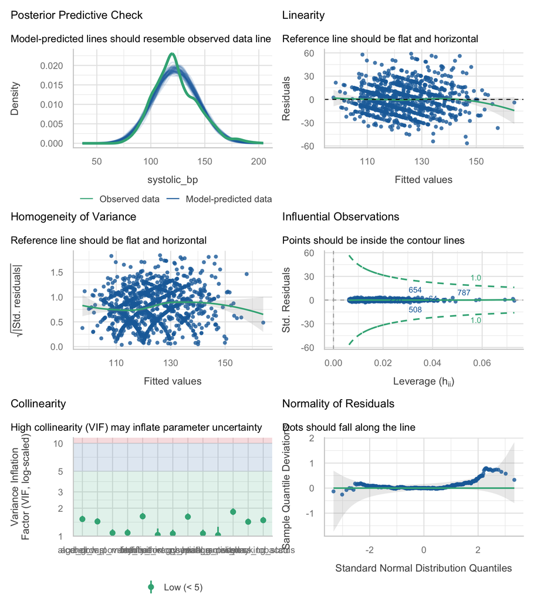

HC3 heteroscedasticity-consistent standard errors

Compared with ordinary least-squares standard errors

| Term | Estimate | SE (OLS) | SE (HC3) | 95% CI (HC3) | p (HC3) |
| --- | --- | --- | --- | --- | --- |
| bmi | 1.370 | 0.127 | 0.126 | 1.12 to 1.62 | <0.001 |
| sexMale | 4.216 | 1.527 | 1.542 | 1.19 to 7.24 | 0.0064 |
| age_group60 or more | 16.322 | 1.652 | 1.779 | 12.83 to 19.81 | <0.001 |
| alcohol_last_monthYes | 6.502 | 1.707 | 1.885 | 2.80 to 10.20 | <0.001 |
| smoking_statusFormer | 8.243 | 1.525 | 1.661 | 4.98 to 11.50 | <0.001 |
| salt_g_per_day | 0.432 | 0.230 | 0.222 | -0.00 to 0.87 | 0.0521 |

# Discussion

**Limitations.** The most serious problem is **treatment bias in the outcome itself**. 131 participants (11.3%) were taking antihypertensive medication when their blood pressure was measured, which lowers the recorded value by an amount that depends on the drug, the dose and adherence, none of which is recorded. Measured systolic pressure in this file is therefore not “blood pressure” but “blood pressure as currently treated”, and because treatment is concentrated in exactly the people whose underlying pressure is highest, every coefficient for a risk factor that also predicts treatment is attenuated. The sensitivity analysis above bounds the problem rather than solving it. Second, **the cluster sampling is not recoverable**: the source study randomly selected only four wards and enrolled roughly 300 participants in each, assuming a design effect of 1.5, but no ward identifier exists in this extract. Consequently the standard errors and confidence intervals reported here are too narrow – plausibly by a factor of around the square root of the design effect, so roughly 20% – and no mixed model or survey-design correction can be fitted to repair them. Estimates from only four clusters also cannot be generalised to Nepal, or even confidently to the whole of Bharatpur. Third, **age is available only in four bands**, so no per-year slope can be estimated and the oldest band (“60 or more”) is open-ended and internally heterogeneous. Fourth, the design is cross-sectional, so all estimates are associations: the former-smoker result is a clear demonstration of reverse causation, and the same logic applies in principle to diet and activity, since people who have been told they have high blood pressure change their behaviour. Fifth, salt intake was estimated rather than measured by 24-hour urinary sodium, and the estimate has essentially no association with blood pressure here, which is at least as likely to reflect measurement error as a true null. Sixth, the model explains only 26.6% of the variance, and residual variance is non-constant. On the credit side, **there is no missing data at all** – all 1159 rows are complete on all 21 variables – so none of the usual complete-case caveats apply.

**Future work.** Refit with the ward identifier as a random effect or survey cluster if the original data can be obtained, and repeat the analysis restricted to participants never treated, using a formal bias-correction (adding a fixed offset of 10-15 mmHg to treated participants’ readings) as a further sensitivity analysis.

# Feasibility notes

*Not part of a student report.*

- **Works, with one large caveat.** A clean continuous outcome, 100% complete data, 1159 rows and 21 parameters, no collinearity (max VIF 1.83), and real confounding that genuinely moves the education coefficients. Adjusted R-squared 0.253.
- **The treatment trap is unavoidable and must be signposted in the brief.** 131 participants are medicated; treated mean systolic 139.8 versus 121 mmHg untreated. A student who ignores this will report attenuated effects as if they were unbiased. Worse, a student who “controls for” `antihypertensive_drug` is adjusting for a consequence of the outcome and will get an even more distorted answer.
- **Forbidden predictors.** `diastolic_bp` (r = 0.79 with the outcome, same measurement occasion), `hypertension` (deterministic function of the outcome), `bp_awareness` and `antihypertensive_drug` (both downstream). Every one of these will look spectacular in a model and every one is circular.
- **Deterministic twins.** `physical_activity` is exactly `mets_min_per_week <= 600`; `cigarettes_per_week` is zero for all never-smokers. Putting both members of either pair into a model is a guaranteed collinearity failure.
- **Heteroscedasticity is certain to be flagged** (p <0.001). This is a good teaching moment provided HC3 is available; the HC3 and OLS standard errors barely differ, so the lesson is “check it, report it, and note it changed nothing”.
- **No ward identifier.** The design effect of 1.5 assumed in the source sample size calculation cannot be honoured. Standard errors are too narrow throughout and this must appear in every report from this dataset.
- **Age in bands only.** Students expecting a “mmHg per year of age” figure cannot have one.
- **Several null lifestyle predictors** (salt, physical activity, fruit and vegetables, family history). This is realistic but disappointing; the brief should warn that a Purpose 3 analysis can legitimately end with most predictors null.